# Lecture 2: Trees and forests

Author

Munir Hiabu

## Trees and forests

- In this lecture we will look at the nonparametric regression problem with squared loss $L(y_1,y_2)=(y_1-y_2)^2$ and also the classification problem with Binary loss function $L(y_1,y_2)=\Bbb 1(y_1\neq y_2)$ or squared loss.
- We already know that the Bayes-rule is
  - $m^\ast(x)=\mathbb E[Y|X=x]$ for the squared loss,
  - $m^\ast(x)=\underset{k=1,\dots,K}{\operatorname{argmax}} \mathbb P(Y=k|X=x)$ for the binary loss.

## Trees and forests Decision trees

- Decision trees are estimators based on a partition of the feature space $\mathcal X$, $E[Y|X=x]=m^\ast(x)=\sin(2\pi x_1)$.

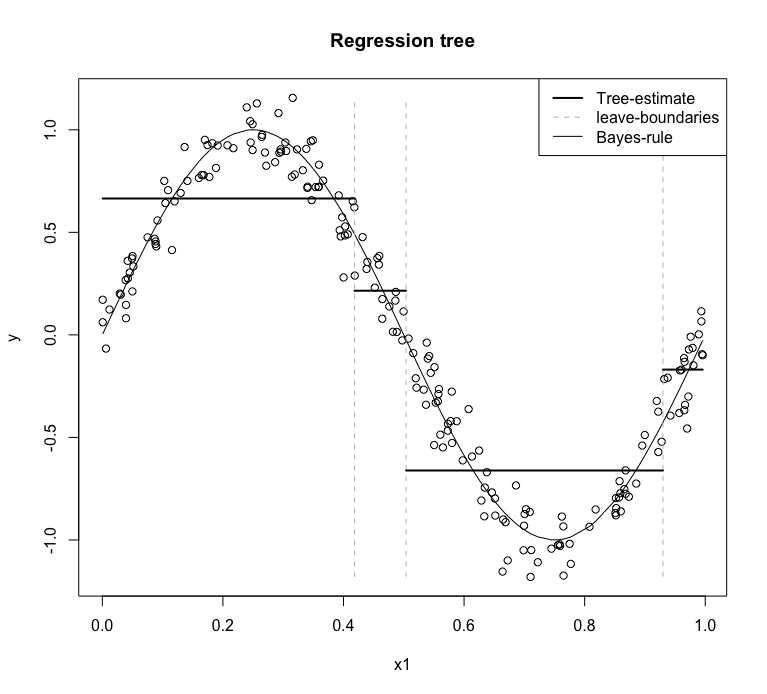

- The tree estimate is a piece-wise constant function.
- The constant areas of the tree estimate are called leaves or terminal nodes.
- The leaves partition the feature space $\mathcal X:$
  - the union of all leaves is equal $\mathcal X$.
  - leaves are non-overlapping, i.e, their intercept is empty.
- The value within a leave is given by averaging the responses (regression with $L_2$ loss) or majority vote (classification with binary loss).

## Trees and forests Tree representation

- Decision trees are popular because the decision making (estimate) is nicely visualizable/interpretable if not too deep:
- Left and right picture below are two different representation of the same tree estimate.
- The interior edges on the right plot are called nodes and can also be interpreted as subset of $\mathcal X$

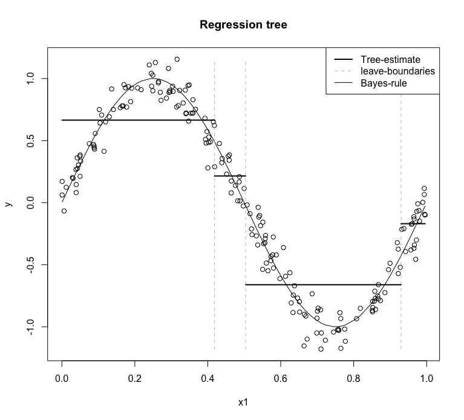

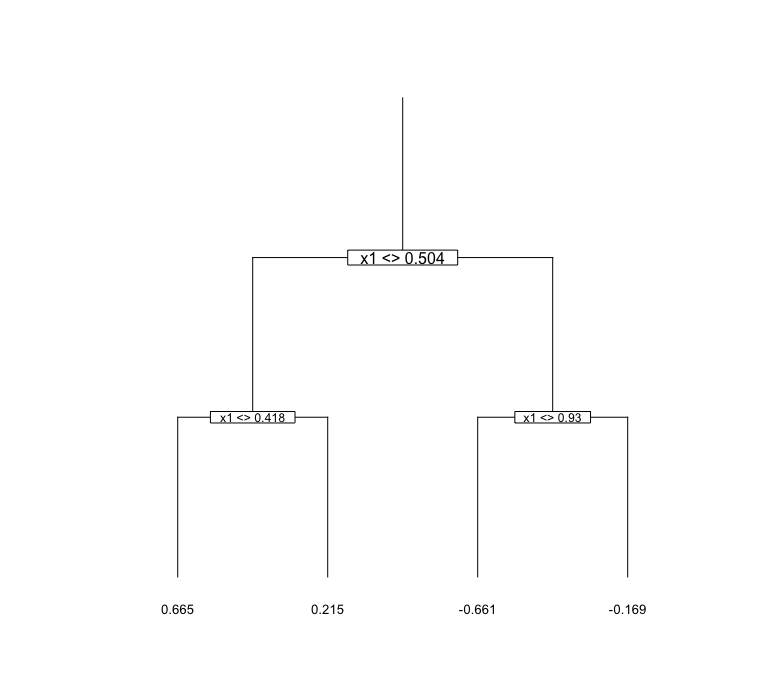

## Trees and forests Tree: Classification example

- Decision trees can be quite efficient in classification tasks where we are interested in 0-1 (binary) decisions.
  - This is the case in many application but is usually not the case in insurance pricing.

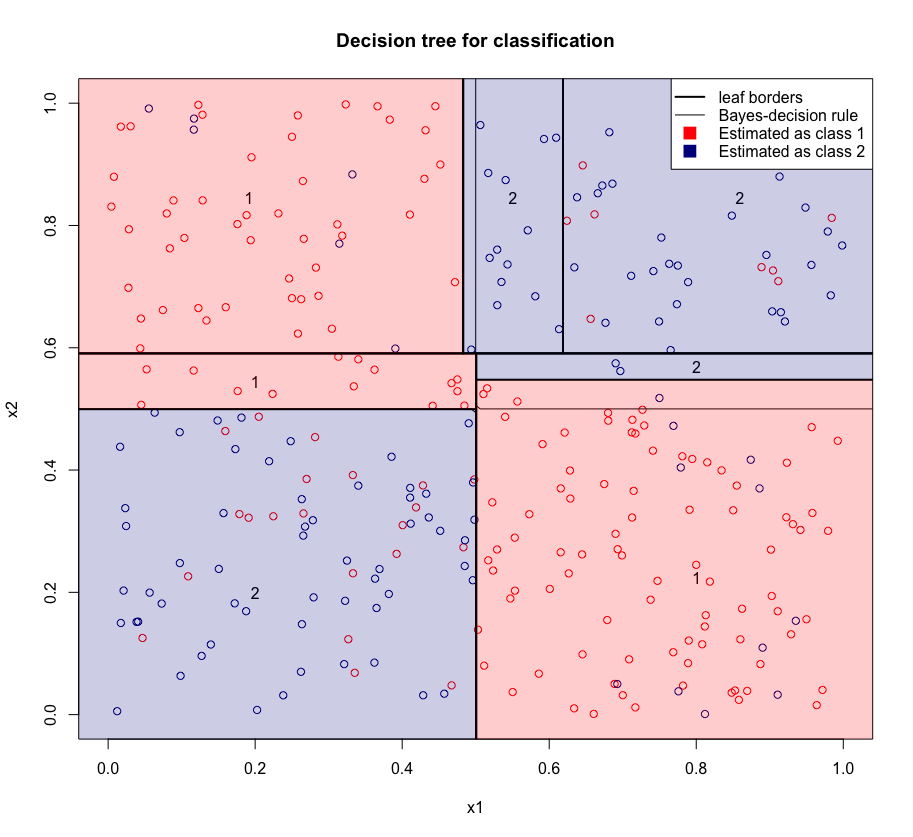

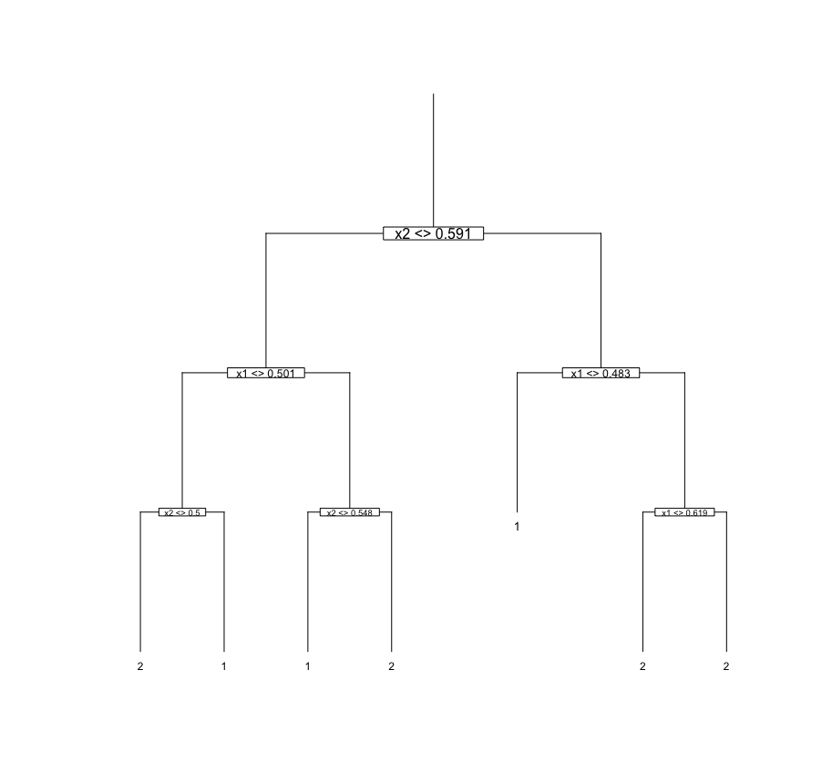

## Trees and forests How to learn a decision tree: CART

- A decision tree is uniquely defined by its leaves.
- Given a tree $T$, we write $m(T)$ for the corresponding regression or classification function.
- The naive approach of looking for leaves $R_1,\dots, R_l$ that minimize a certain loss is practically not feasible because of the computational cost.
- Instead: top-down greedy approach, called CART (classification and regression trees).
- We now describe how to construct nodes via the CART algorithm.

**CART (heuristic)**

- Start with the whole space $\mathcal X$ (=root node).
- Pick variable (i.e. component of $X$) and split-point that minimises a loss criterion.
- Split $\mathcal X$ into two nodes according to variable and split point.
- Next, if no stopping rule applies, both nodes (otherwise only one or none) are split into two further nodes.
- Continue until stopping rule applies to all nodes.

## Trees and forests How to learn a decision tree: CART

**CART algorithm (start)**

Start with $\mathcal X$ as initial node for splitting.

**CART algorithm (splitting)**

- Input: node $N\subseteq \mathcal X$
- For every dimension $j=1,\dots,p$ and every point $s_j\in \{x_j| \exists\ x_1,\dots,x_{j-1},x_{j+1},\dots,x_p\ \text{with} (x_1,\dots,x_p)\in N\}$ define
  $$N_1(j,s_j)=\{(x_1,\dots,x_p)\in N| \ x_j \leq s_j\}, \quad N_2(j,s_j)=\{(x_1,\dots,x_p)\in N| \ x_j > s_j\}.$$
- We pick the minimizer
  $$(j^\ast,s^\ast)= \arg\min_{j,s} Q_n(N_1(j,s_j)) + Q_n(N_2(j,s_j))$$
- Each of the new nodes $(N_1(j^\ast,s^\ast),N_2(j^\ast,s^\ast))$ is further split as long as stopping criterion does not apply.

## Trees and forests How to learn a decision tree: CART

**CART Algorithm: the loss $Q$**

For regression the most common loss function is the squared loss:

- Squared loss: $Q_n(N_l)= \sum_{i: X_i \in N_l} (Y_i - \overline Y_i(N_l))^2$
  - $\overline Y_i(N_l)= \frac 1 {|N_l|}\sum_{i: X_i \in N_l}Y_i,$ $|N_j|=\#\{i: X_i\in N_j\}$.

In the classification case, define $\hat p_{lk}= \frac 1 {|N_l|} \sum_{i: X_i \in N_l} \mathbb 1(Y_i=k)$ (=the proportion of class $k$ observation in $N_l$)

Common loss functions are:

- Brier score: $Q_n(N_l)= \sum_{i: X_i \in N_l} (Y_i - \overline Y_i(N_l))^2$ (=squared loss)
- Misclassification error: $Q_n(N_l)= 1 - \max_{k}\hat p_{lk}$
- Gini index: $Q_n(N_l)= \sum_{k=1}^K \hat p_{lk}(1-\hat p_{lk})$
- Entropy : $Q_n(N_l)=-\sum_{k=1}^K \hat p_{lk}\log\hat p_{lk}$
- Note: In classification, even if binary loss is the ultimate goal, Gini index and entropy might be the better choices for splitting.

## Trees and forests How to learn a decision tree: CART

**CART algorithm (stopping criterion)**

- The most common stopping criterion is specifying a min-node size, i.e. stop if $|R_j|<c$. A common choice is $c=5$.
- An alternative stopping criteria is the depth of $R_j$, i.e., the number of parent nodes of $R_j$.

## Trees and forests How to learn a decision tree: CART, Pruning

- The process described so far will probably lead to an overfit.
- One may think that one way out is to stop growing the tree early enough.
  - This is not advisable because stopping the growing early because the current split does not lead to great improvement in the loss does not mean that a split afterwards might not turn very effective.
- In the problem below, the first split will not lead to big improvements in the loss. We will need at least 2 (probably more) splits until we arrive at a good decision rule.

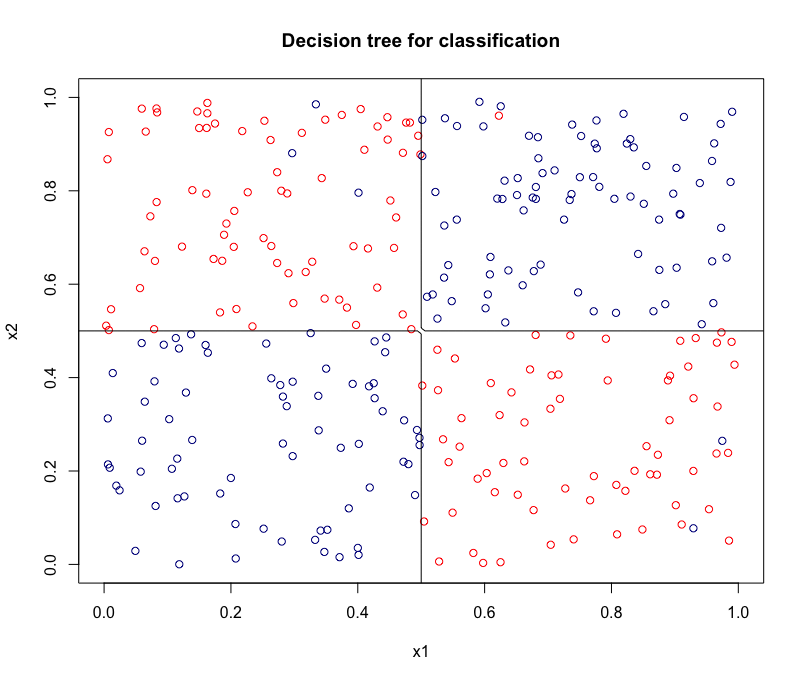

## Trees and forests How to learn a decision tree: CART, Pruning

- The idea of pruning is to let a tree grow very deep first (= small min node size) and then select a subtree (pruning) as final fit.
- Idea: We can compare different subtrees via a penalized loss.

**Definition (Subtree)**

We call $T'$ a subtree of $T$ if

- the nodes of $T'$ is a subset of the nodes of $T$
- $T'$ and $T$ have the same root.

If $T'$ is a subtree of $T$, we also write $T'\subseteq T$

- We can derive a subtree, by pruning a tree at any non-terminal node (i.e. by deleting all descendants of that node)

## Trees and forests How to learn a decision tree: CART, Pruning

**Definition ($\alpha$-pruned tree)**

Consider a tree $\hat T_n$ with corresponding estimator $\hat m_n(\hat T_n)$. Given a parameter $\alpha>0$, the $\alpha$-pruned tree is
$$\hat T_{n,\alpha} := \arg \min_{T\subseteq \hat T_n}\{\hat R_n(\hat m_n) + \alpha |T|\},$$
where $|T|$ is the number of leaves of $T$.

- How do we find an optimal $\alpha$ (and also the optimal subtree for a fixed )?
  - brute force cross-validation will be too computationally intensive even if we know the answer to the second question.
  - The answer to both questions is the weakest link algorithm.

## Trees and forests How to learn a decision tree: CART, Pruning

**Proposition (weakest link, see Breiman (1984))**

$\hat T_{n,\alpha}$ is unique. Furthermore, there are trees $T_0\supset \cdots\supset T_l$ with $\{T_0,\dots, T_l\}=\{\hat T_{n,\alpha} : \alpha>0\}$; in particular the set $\{\hat T_{n,\alpha} : \alpha>0\}$ is finite. Let $\widetilde Q_n$ be the loss function corresponding to $\hat R_n$. The trees $T_0,\dots, T_l$ can be found with the following algorithm

1. Let $t_L,t_R$ be any two terminal nodes in $\hat T_n$ resulting from a split of the immediate ancestor node t. If $\widetilde Q_n(t) = \widetilde Q_n(t_L)+\widetilde Q_n(t_R)$, prune off $t_L$ and $t_R$. Continue this process until no more pruning is possible. The resulting tree is $T_0$.
2. $k=0$
3. Go through all non-terminal nodes $t$ of $T_k$ and calculate
   $$g(t)=\frac{\widetilde Q_n(t)-\widetilde Q_n(T_t)}{|T_t|-1},$$
   where $T_t$ is the tree (branch) with root $t$ and nodes consisting of $t$ and the descendants of $t$ in $T_k$. $\widetilde Q_n(T_t)=\sum_{t \ \text{leaf of}\ T_t} \widetilde Q_n(t)$.
4. $\alpha= \min_{t \ \text{ non-terminal node of} \ T_k}g(t)$.
5. From top to bottom in $T_k$ prune all non-terminal nodes with $g(t)=\alpha$ and call the resulting tree $T_{k+1}$.
6. If $T_{k+1}$ has more than one node, set $k \leftarrow k+1$ and go to step 3.

## Trees and forests How to learn a decision tree: CART, Pruning

- Given $l$ trees $\{T_0,\dots, T_l\}=\{\hat T_{n,\alpha} : \alpha>0\}$, we can pick the optimal tree via cross validation.

**Problem with decision trees**

There are (at least) two major problems with decision trees

- Instability: Small variations in the data can lead to a very different tree
- Performance: The performance (measured via test error) is usually much weaker compared to other learning algorithms

## Trees and forests Problem of trees: Instability

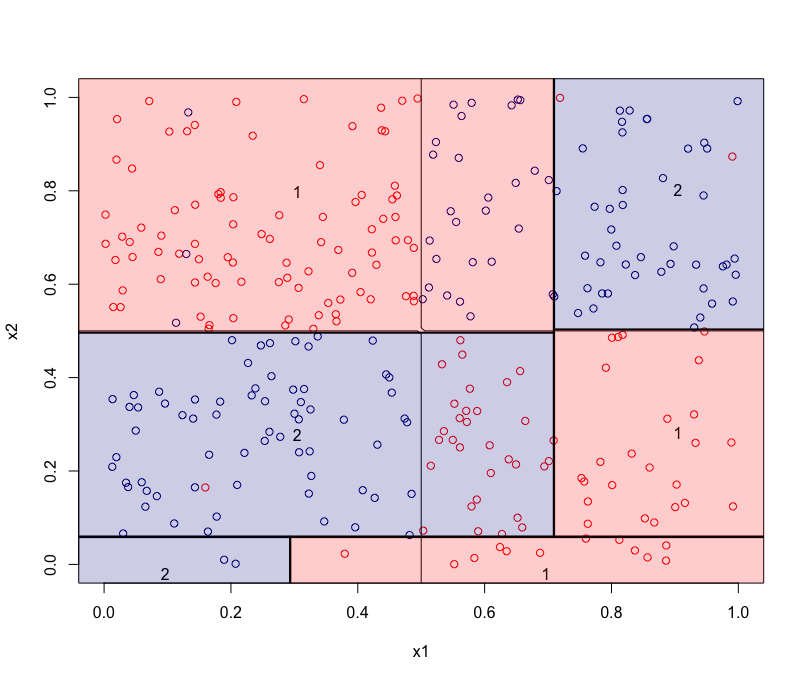

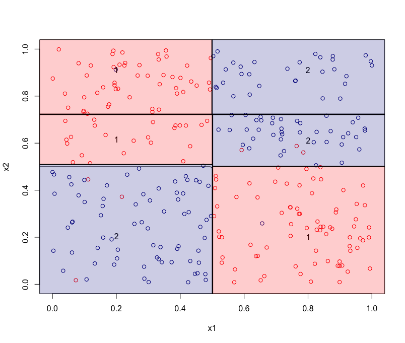

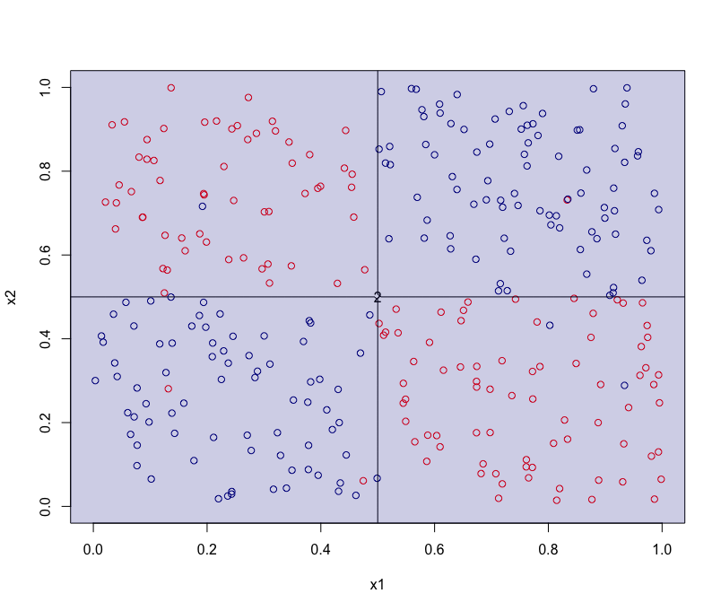

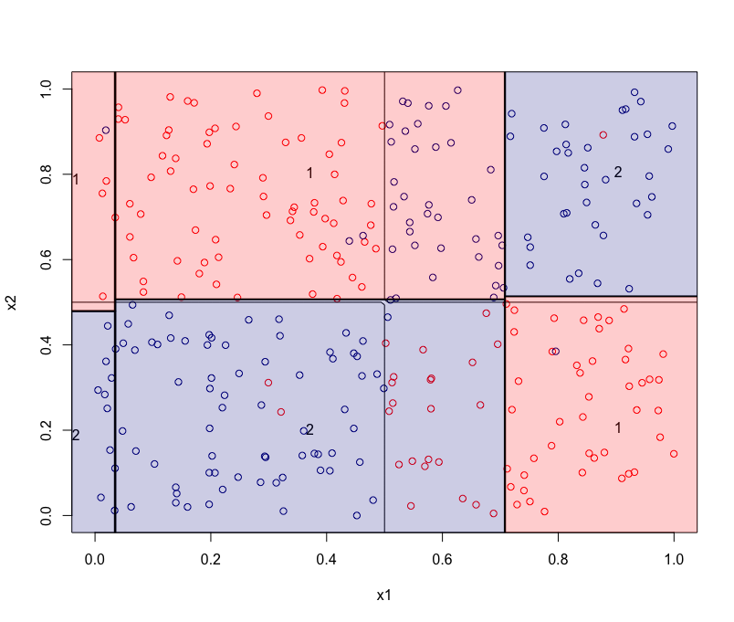

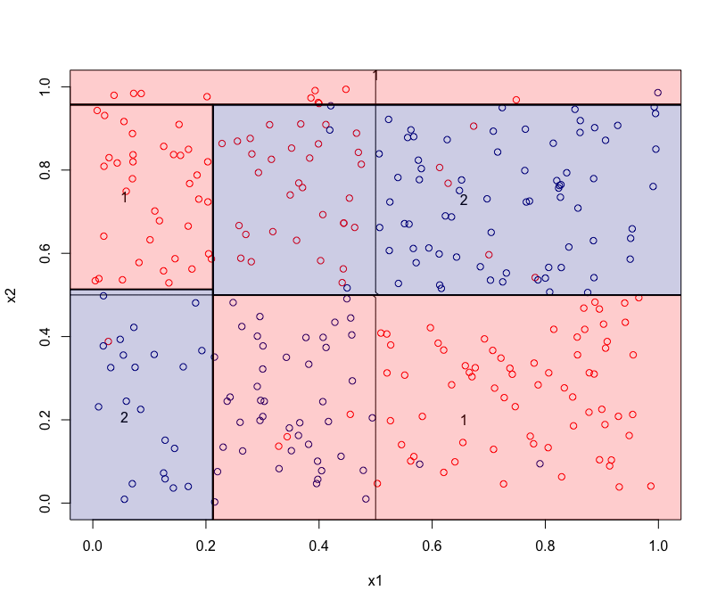

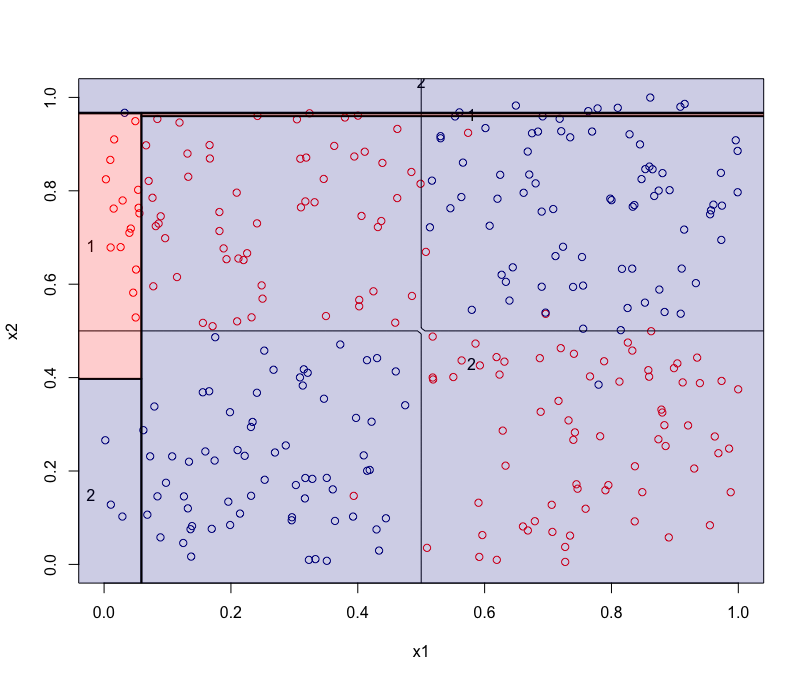

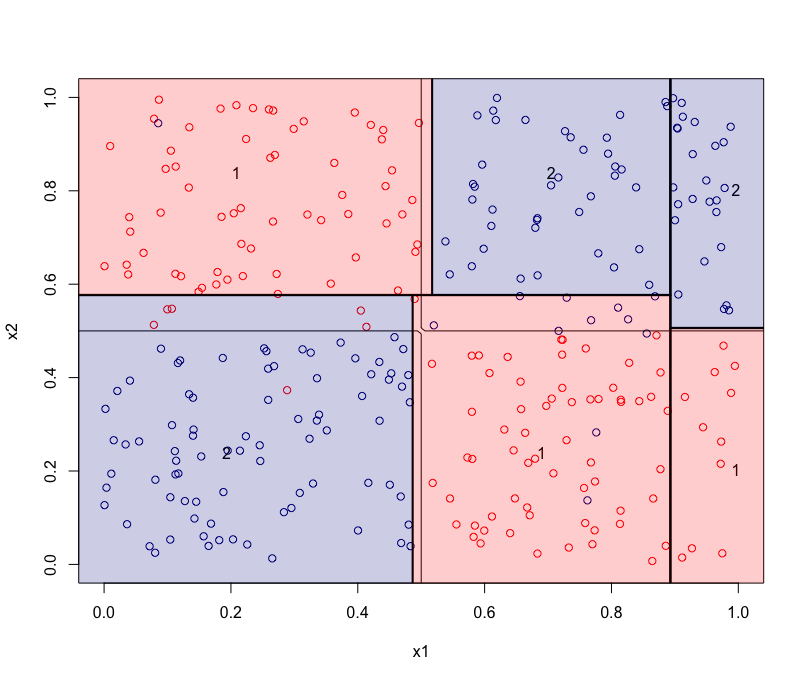

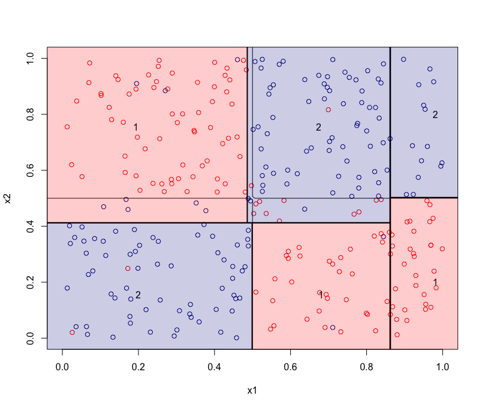

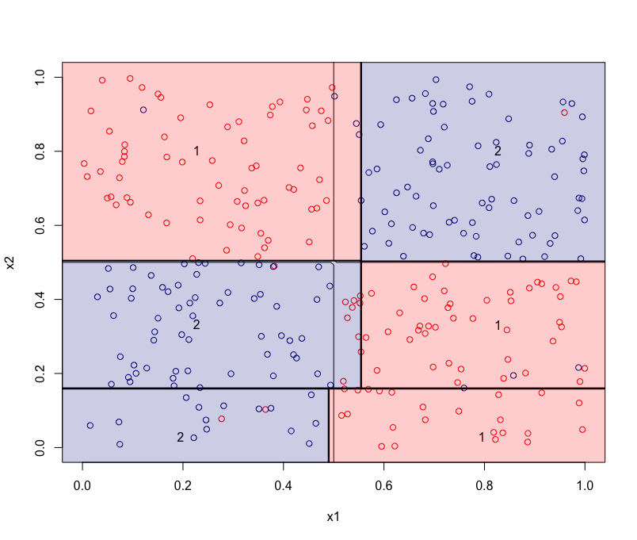

## Trees and forests Bagging

- Bagging stands for Bootstrap aggregation.
- Idea: Generate artificial data via bootstrap, build a decision tree for each data-set and average.
- Hope: It reduces the variance of decision trees.

**Definition (Bagging)**

- Given data ${(X_1,Y_1),\dots, (X_n,Y_n)}$, draw $B$ bootstrap samples $\tilde {\mathcal D}^{(b)}_n={(\tilde X^{(b)}_1,\tilde Y^{(b)}_1),\dots, (\tilde X^{(b)}_n,\tilde Y^{(b)}_n)}, b=1,\dots, B$, i.e., $\tilde {\mathcal D}^{(b)}_n$ arises from $\mathcal D_n$ by drawing $n$ times with replacement.
- The bagging estimator is defined as
  - squared loss $\rightarrow$ average: $\hat m^{bagg}_n=\frac 1 B \sum_{b=1}^B \hat m_n(\tilde {\mathcal D}^{(b)}_n)$
  - binary loss $\rightarrow$ majority vote: $\hat m^{bagg}_n(x)=\arg \max_{k\in {1,\dots K}} \#\{b: m_n(\tilde {\mathcal D}^{(b)}_n) (x)=k\}$
- Note that $\hat m^{bagg}_n$ is a stochastic estimator, even given $\mathcal D_n$.
- Note: Usually, bagging is applied on non-pruned trees. (See it as an alternative way to reduce variance)

## Trees and forests Random forests

- While bagging improves performance of decision trees, interpretability is worsened.
- If interpretability is not a concern, then bagging is still inferior compared to other learning techniques.
- Random forests are a modification on bagging estimators.

**Definition (Random forest)**

- As bagging random forest are an ensemble of decision trees.
- They add the following modification to bagging:
  - $\texttt{mtry}$: Each time a node is split it is only done on a subset of size $\texttt{mtry}$ of viable variables. I.e., each time you want to split a node, turn on a random generator and draw $1\leq\texttt{mtry}<p$ viable variables from $\{1,\dots,p\}$. Only those variables drawn are allowed to be considered for the next split.
- We denote the random forest estimator by $\hat m^{rf}_n$. Note that $\hat m^{rf}_n$, as $\hat m^{bagg}_n$, is a stochastic estimator, even given $\mathcal D_n$.

## Trees and forests Random forests

**Why is $\texttt{mtry}$ so useful?**

- Assume that we are given $l$ estimators $m_n(\mathcal D_n, U_1), \dots m_n(\mathcal D_n, U_l)$
- Here, $U_1,\dots, U_l$ are iid variables inducing the additional stochasticity of the estimators (e.g. through random forest or bagging).
- Assume that $\hat m_n(\mathcal D_n, U_1), \dots \hat m_n(\mathcal D_n, U_l)$ have pairwise correlation $\rho$ and variance $\sigma^2$.
- We get
  $$\begin{aligned}
  \textrm{Var}\left (\frac 1 l \sum_{j=1}^l \hat m_n(\mathcal D_n, U_j)\right)&= \frac 1 {l^2} \sum_{jk} \textrm{Cov}(m_n(\mathcal D_n, U_j),m_n(\mathcal D_n, U_k))\\&=\frac 1 {l^2} \left( l\sigma^2+ (l^2-l)\rho\sigma^2\right)\\&= \rho \sigma^2 + \frac{1-\rho}{l}\sigma^2
  \end{aligned}$$
- Meaning: Variance of an ensemble of trees is small the smaller the correlation between the trees.
  - The $\texttt{mtry}$ parameter aims to make trees less alike and hence more uncorrelated.

## Trees and forests Random forests: Pros and Cons

- Random forest are competitive to many state of the art learners.
- While not having “best performance” in terms off accuracy they are not too far behind.
- Advantages of random forests are
  - Default hyperparameters already lead to very strong results (i.e. without tuning hyperparameter)
    - $\texttt {mtry}=\lfloor \sqrt{p}\rfloor$
    - min node size= 1 for classification, 5 for regression
  - Can be implemented (and is implemented) very fast
- Random forest (and also trees) don’t perform well for additive functions
  - see next slide

## Trees and forests Random forests: Pros and Cons

**Decision trees are not good with additive functions (example)**

- Consider $m^\ast(x) = \sum_j^p \mathbb 1(x_j \leq 0)$ for large $p$.
- For a perfect fit, a tree algorithm would have to grow a tree with depth $p$, where each leaf is the result of splitting once with respect to each covariate.
- Hence, we end up with $2^p$ leaves, which on average contain $n/(2^p)$ data points.
- Even if all splits are optimal for $2^p>n$, the tree will not be able to lead to a perfect decision rule.

## Trees and forests Random forests: Pros and Cons

- While predictions of random forests are relatively smooth, they are not monotonic.
  - e.g. in car insurance, if everything else is the same, more mileage should lead to higher insurance price.
- Random forests deal well with sparsity, i.e., when the number of features $p$ is large, but the number of relevant features is rather small: $s<<p$.

## References

Breiman, Leo. 1984. *Classification and Regression Trees*. Routledge.